# DATA SCIENCE LATAM

UN ESPACIO PARA NUNCA PARAR DE APRENDER!!

Francisco Zambrano Cruz. Mayo 2020.

[figure not shown]

# Descomposición de Series de Tiempo

Los datos de series de tiempo pueden exhibir una variedad de patrones, y a menudo es útil dividir una serie de tiempo en varios componentes, cada uno de los cuales representa una categoría de patrón subyacente.

En la Sección de [Graficas de series de tiempo](https://zpio.github.io/datascience/post/Gr%C3%A1ficos_Series_Tiempo_R.html) vimos tres tipos de patrones de series de tiempo: **tendencia, estacionalidad y ciclos**. Cuando descomponemos una serie temporal en componentes, generalmente combinamos la tendencia y el ciclo en un solo componente de ciclo de tendencia (a veces llamado tendencia por simplicidad). Por lo tanto, pensamos que una serie de tiempo comprende tres componentes: un componente de ciclo de tendencia, un componente estacional y un componente residuo.

A continuacion, consideramos algunos métodos comunes para extraer estos componentes de una serie de tiempo. A menudo, esto se hace para ayudar a mejorar la comprensión de las series de tiempo, pero también se puede usar para mejorar la precisión del pronóstico.

## 1. Componentes de Series de Tiempo

Si suponemos una **descomposición aditiva**, entonces podemos escribir:

$$y_{t} = S_{t} + T_{t} + R_t$$

donde **yt** son los **datos**, **St** es el **componente estacional**, **Tt** es el **componente del ciclo de tendencia**, y **Rt** es el **componente residuo**, todo en el **período t**.

Alternativamente, una **descomposición multiplicativa** se escribiría como:

$$y_{t} = S_{t} \times T_{t} \times R_t$$

*La **descomposición aditiva** es la más apropiada si la magnitud de las fluctuaciones estacionales, o la variación alrededor del ciclo de tendencia, no varía con el nivel de la serie temporal*.

Cuando la variación en el patrón estacional, o la variación alrededor del ciclo de tendencia, parece ser proporcional al nivel de la serie de tiempo, entonces una **descomposición multiplicativa** es más apropiada. Las descomposiciones multiplicativas son comunes con las series de tiempo económicas.

Una **alternativa al uso de una descomposición multiplicativa** es transformar primero los datos hasta que la variación en la serie parezca ser estable en el tiempo, luego usar una descomposición aditiva. Cuando se ha usado una transformación logarítmica, esto es equivalente a usar una descomposición multiplicativa porque

$$y_{t} = S_{t} \times T_{t} \times R_t \quad\text{es equivalente a }\quad \log y_{t} = \log S_{t} + \log T_{t} + \log R_t$$

### Fabricacion de equipos electricos

Analizaremos varios métodos para obtener los componentes St, Tt y Rt más adelante, pero primero, es útil ver un ejemplo. Descompondremos el **índice de nuevos pedidos de equipos eléctricos** que se muestra en la **Figura 1**. Los datos muestran el número de nuevos pedidos de equipos eléctricos (productos informáticos, electrónicos y ópticos) en 16 países. Los datos han sido ajustados por días hábiles y normalizados.

**FIGURA 1**

[figure not shown]

La Figura 1 muestra el componente del ciclo de tendencia, Tt, en rojo y los datos originales, yt, en gris. El ciclo de tendencia muestra el movimiento general en la serie, ignorando la estacionalidad y cualquier pequeña fluctuación aleatoria.

La figura 2 muestra una descomposición aditiva de estos datos. El **método** utilizado para estimar componentes en este ejemplo es **STL("Descomposición estacional y de tendencia usando Loess")**.

**FIGURA 2**: Los pedidos de equipos eléctricos y sus tres componentes aditivos.

[figure not shown]

Los tres componentes se muestran por separado en los tres paneles inferiores de la Figura 2. Estos componentes se pueden agregar para reconstruir los datos que se muestran en el panel superior. Tenga en cuenta que el componente estacional cambia lentamente con el tiempo, de modo que dos años consecutivos tienen patrones similares, pero años muy separados pueden tener patrones estacionales diferentes. El componente residuo que se muestra en el panel inferior es lo que queda cuando los componentes estacionales y de ciclo de tendencia se han restado de los datos.

Las **barras grises** a la derecha de cada panel muestran las **escalas relativas** de los componentes. Cada barra gris representa la misma longitud pero debido a que las plots están en escalas diferentes, las barras varían en tamaño. La gran barra gris en el panel inferior muestra que la variación en el componente residuo es pequeña en comparación con la variación en los datos, que tiene una barra de aproximadamente un cuarto del tamaño. Si redujimos los tres paneles inferiores hasta que sus barras se convirtieron en el mismo tamaño que en el panel de datos, entonces todos los paneles estarían en la misma escala.

### Datos sin la componente estacional

Si el componente estacional se elimina de los datos originales, los valores resultantes son los **"datos desestacionalizados"**. Para una descomposición aditiva, los datos desestacionalizados están dados por **yt-St**, y para datos multiplicativos, los valores datos desestacionalizados se obtienen usando **yt/St**.

La FIGURA 3 muestra los pedidos de equipos eléctricos sin la componente estacional:

[figure not shown]

Si la variación debido a la estacionalidad no es de interés primario, la serie ajustada estacionalmente puede ser útil. Por ejemplo, los datos mensuales de desempleo generalmente se ajustan estacionalmente para resaltar la variación debido al estado subyacente de la economía en lugar de la variación estacional. Un aumento en el desempleo debido al abandono escolar que busca trabajo es una variación estacional, mientras que un aumento en el desempleo debido a una recesión económica no es estacional.

*La mayoría de los analistas económicos que estudian los datos de desempleo están más interesados en la variación no estacional. En consecuencia, los datos de empleo (y muchas otras series económicas) generalmente se ajustan estacionalmente*.

Las series desestacionalizadas contienen el componente residuo, así como el ciclo de tendencia. Por lo tanto, no son "suaves" y las "bajadas" o "subidas" pueden ser engañosas. Si el propósito es buscar puntos de inflexión en una serie e interpretar cualquier cambio de dirección, entonces es mejor usar el componente del ciclo de tendencia en lugar de los datos ajustados estacionalmente.

## 2. Medias Moviles

El **método clásico de descomposición de series temporales** se originó en la década de 1920 y se utilizó ampliamente hasta la década de 1950. Todavía forma la base de muchos métodos de descomposición de series temporales, por lo que es importante comprender cómo funciona. El primer paso en una **descomposición clásica** es usar un método de **promedio móvil** para estimar el ciclo de tendencia, por lo que comenzamos discutiendo los promedios móviles.

### Moving average smoothing

Un promedio móvil de orden m Se puede escribir como:

Ecuacion 1:

$$\begin{equation} \hat{T}_{t} = \frac{1}{m} \sum_{j=-k}^k y_{t+j} \end{equation}$$

donde m=2k+1. Es decir, la estimación del ciclo de tendencia en el tiempo t se obtiene promediando los valores de las series de tiempo dentro de k períodos de t. También es probable que las observaciones cercanas en el tiempo tengan un valor cercano. Por lo tanto, el promedio elimina parte de la aleatoriedad en los datos, dejando un componente de ciclo de tendencia suave. Llamamos a esto un **m-MA**, que significa un promedio móvil de orden m.

```r
library(ggplot2)
library(fpp2)
```

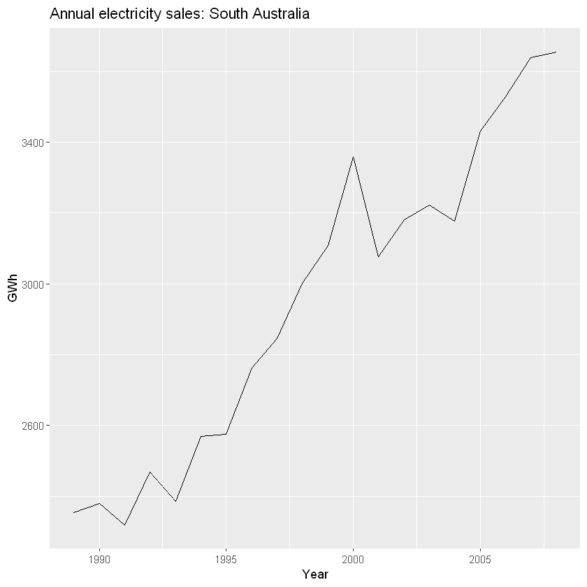

```r
#FIGURA 4: Ventas de electricidad residencial (excluyendo agua caliente) para Australia del Sur: 1989–2008.

autoplot(elecsales) + xlab("Year") + ylab("GWh") +
  ggtitle("Annual electricity sales: South Australia")
```

```r
elecsales

#Time Series:
#Start = 1989
#End = 2008
#Frequency = 1
#[1] 2354.34 2379.71 2318.52 2468.99 2386.09 2569.47 2575.72 2762.72 2844.50 3000.70 3108.10 3357.50
#[13] 3075.70 3180.60 3221.60 3176.20 3430.60 3527.48 3637.89 3655.00
```

Tabla 1: Ventas anuales de electricidad a clientes residenciales en Australia del Sur. 1989-2008.

[figure not shown]

En la última columna de esta tabla, se muestra un promedio móvil de orden 5, que proporciona una estimación del ciclo de tendencia. El primer valor en esta columna es el promedio de las primeras cinco observaciones (1989–1993); el segundo valor en la columna 5-MA es el promedio de los valores para 1990-1994. Cada valor en la columna 5-MA es el promedio de las observaciones en la ventana de cinco años centrada en el año correspondiente. En la notación de la ecuación 1, la columna 5-MA contiene los valores de $\hat{T}_{t}$ con k=2 y m=2k+1=5. Esto se calcula fácilmente usando:

```r
ma(elecsales, 5)

#Time Series:
#Start = 1989
#End = 2008
#Frequency = 1
#[1]       NA       NA 2381.530 2424.556 2463.758 2552.598 2627.700 2750.622 2858.348 3014.704 3077.300
#12] 3144.520 3188.700 3202.320 3216.940 3307.296 3398.754 3485.434       NA       NA
```

No hay valores para los dos primeros años o los últimos dos años, porque no tenemos dos observaciones en ninguno de los lados. Más adelante utilizaremos métodos más sofisticados de estimación del ciclo de tendencia que permiten estimaciones cerca de los puntos finales.